# IODS course project

## Modifying the dataset

First we standardize the dataset and print out the summaries of the scaled data. From the summary we can see, that the means of the scaled variables are zero. This means that the variables are centered.

```
##       crim                 zn               indus
##  Min.   :-0.419367   Min.   :-0.48724   Min.   :-1.5563
##  1st Qu.:-0.410563   1st Qu.:-0.48724   1st Qu.:-0.8668
##  Median :-0.390280   Median :-0.48724   Median :-0.2109
##  Mean   : 0.000000   Mean   : 0.00000   Mean   : 0.0000
##  3rd Qu.: 0.007389   3rd Qu.: 0.04872   3rd Qu.: 1.0150
##  Max.   : 9.924110   Max.   : 3.80047   Max.   : 2.4202
##       chas              nox                rm               age
##  Min.   :-0.2723   Min.   :-1.4644   Min.   :-3.8764   Min.   :-2.3331
##  1st Qu.:-0.2723   1st Qu.:-0.9121   1st Qu.:-0.5681   1st Qu.:-0.8366
##  Median :-0.2723   Median :-0.1441   Median :-0.1084   Median : 0.3171
##  Mean   : 0.0000   Mean   : 0.0000   Mean   : 0.0000   Mean   : 0.0000
##  3rd Qu.:-0.2723   3rd Qu.: 0.5981   3rd Qu.: 0.4823   3rd Qu.: 0.9059
##  Max.   : 3.6648   Max.   : 2.7296   Max.   : 3.5515   Max.   : 1.1164
##       dis               rad               tax             ptratio
##  Min.   :-1.2658   Min.   :-0.9819   Min.   :-1.3127   Min.   :-2.7047
##  1st Qu.:-0.8049   1st Qu.:-0.6373   1st Qu.:-0.7668   1st Qu.:-0.4876
##  Median :-0.2790   Median :-0.5225   Median :-0.4642   Median : 0.2746
##  Mean   : 0.0000   Mean   : 0.0000   Mean   : 0.0000   Mean   : 0.0000
##  3rd Qu.: 0.6617   3rd Qu.: 1.6596   3rd Qu.: 1.5294   3rd Qu.: 0.8058
##  Max.   : 3.9566   Max.   : 1.6596   Max.   : 1.7964   Max.   : 1.6372
##      black             lstat              medv
##  Min.   :-3.9033   Min.   :-1.5296   Min.   :-1.9063
##  1st Qu.: 0.2049   1st Qu.:-0.7986   1st Qu.:-0.5989
##  Median : 0.3808   Median :-0.1811   Median :-0.1449
##  Mean   : 0.0000   Mean   : 0.0000   Mean   : 0.0000
##  3rd Qu.: 0.4332   3rd Qu.: 0.6024   3rd Qu.: 0.2683
##  Max.   : 0.4406   Max.   : 3.5453   Max.   : 2.9865
```

From the scaled variable of the *per capita crime rate by town* we create a categorical variable of the crime rate. We use quantiles as a base of categorization. As a result we get a variable that divides the towns of Boston to *low*, *medium low*, *medium high* and *high* crime rates.

```
## crime
##      low  med_low med_high     high
##      127      126      126      127
```

Finally we divide the dataset to **train** (80 per cent) and **test** (20 per cent) datasets.

## Linear Discriminant Analysis (LDA)

Next we conduct LDA on the **train set** using the categorical crime rate variable as target variable. As a result we draw a LDA (bi)plot.

```
## Call:
## lda(crime ~ ., data = train)
##
## Prior probabilities of groups:
##       low   med_low  med_high      high
## 0.2623762 0.2425743 0.2400990 0.2549505
##
## Group means:
##                  zn      indus        chas        nox         rm
## low       0.9216378 -0.9015964 -0.12375925 -0.8590692  0.4305702
## med_low  -0.1221282 -0.3028408 -0.07145661 -0.5407018 -0.1425889
## med_high -0.3705437  0.1547552  0.21473488  0.4082317  0.1533950
## high     -0.4872402  1.0170891 -0.08120770  1.0552984 -0.4456755
##                 age        dis        rad        tax     ptratio
## low      -0.8785970  0.9114170 -0.6969214 -0.7362545 -0.38384582
## med_low  -0.3113333  0.3165519 -0.5400630 -0.4779569 -0.03743457
## med_high  0.4197253 -0.3766785 -0.4111897 -0.3243804 -0.37612793
## high      0.8198042 -0.8711781  1.6384176  1.5142626  0.78111358
##                black       lstat        medv
## low       0.37746369 -0.76483622  0.49638526
## med_low   0.30973476 -0.13329093 -0.02919621
## med_high  0.09610176 -0.02111664  0.23687172
## high     -0.88422920  0.94436000 -0.77924386
##
## Coefficients of linear discriminants:
##                  LD1         LD2          LD3
## zn       0.097148934  0.62896894 -0.920386596
## indus    0.061206804 -0.22380843  0.217180254
## chas    -0.108515993 -0.09156799  0.004994214
## nox      0.316990550 -0.72276662 -1.377435359
## rm      -0.101993997 -0.05252027 -0.160476860
## age      0.234076662 -0.39564882 -0.140860252
## dis     -0.103856526 -0.23525785 -0.082962098
## rad      3.463669343  0.81418225 -0.122855402
## tax      0.000643629  0.02734672  0.463249429
## ptratio  0.067491461  0.09694752 -0.288192685
## black   -0.116209625  0.02223459  0.131456872
## lstat    0.229829509 -0.16788296  0.339953326
## medv     0.172462268 -0.42107543 -0.322481077
##
## Proportion of trace:
##    LD1    LD2    LD3
## 0.9571 0.0317 0.0112
```

```
## function(x, myscale = 1, arrow_heads = 0.1, color = "red", tex = 0.75, choises = c(1,2)){
##     heads <- coef(x)
##     arrows(x0 = 0, y0 = 0,
##            x1 = myscale * heads[,choises[1]],
##            y1 = myscale * heads[,choises[2]], col = color, length = arrow_heads)
##     text(myscale * heads[,choises], labels = row.names(heads),
##          cex = tex, col = color, pos = 3)
## }
```

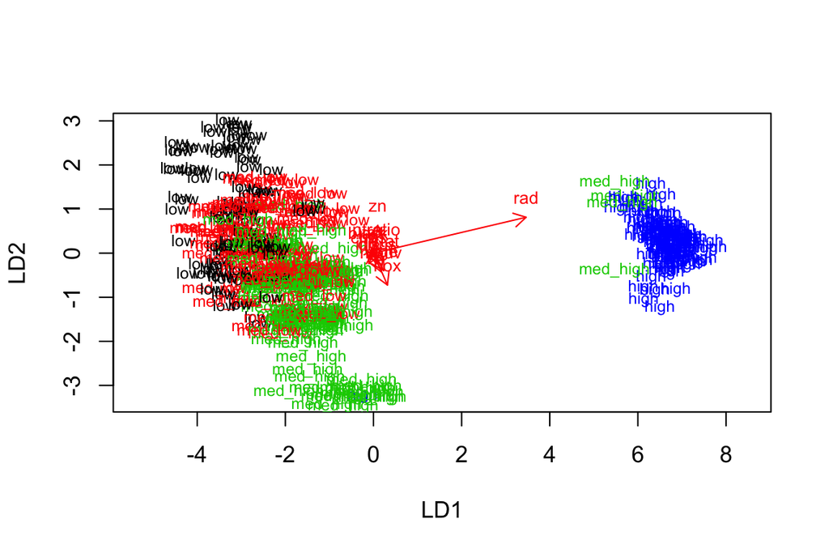

## Predicting the classes with LDA model

```
##           predicted
## correct    low med_low med_high high
##   low       14       7        0    0
##   med_low    7      17        4    0
##   med_high   0      14       13    2
##   high       0       0        0   24
```